# LinearRegression

## Linear Regression

Basic Example of Linear Regression Implementation

## About the data

Buying and selling used phones and tablets used to be something that happened on a handful of online marketplace sites. But the used and refurbished device market has grown considerably over the past decade. Refurbished and used devices continue to provide cost-effective alternatives to both consumers and businesses that are looking to save money when purchasing one. There are plenty of other benefits associated with the used device market. Used and refurbished devices can be sold with warranties and can also be insured with proof of purchase. Third-party vendors/platforms, such as Verizon, Amazon, etc., provide attractive offers to customers for refurbished devices. Maximizing the longevity of devices through second-hand trade also reduces their environmental impact and helps in recycling and reducing waste

The rising potential of this comparatively under-the-radar market fuels the need for an ML-based solution to develop a dynamic pricing strategy for used and refurbished devices. ReCell, a startup aiming to tap the potential in this market, has hired you as a data scientist. They want you to analyze the data provided and build a linear regression model to predict the price of a used phone/tablet and identify factors that significantly influence it.

The data contains the different attributes of used/refurbished phones and tablets. The detailed data dictionary is given below.

**Data Dictionary**

- brand_name: Name of manufacturing brand
- os: OS on which the device runs
- screen_size: Size of the screen in cm
- 4g: Whether 4G is available or not
- 5g: Whether 5G is available or not
- main_camera_mp: Resolution of the rear camera in megapixels
- selfie_camera_mp: Resolution of the front camera in megapixels
- int_memory: Amount of internal memory (ROM) in GB
- ram: Amount of RAM in GB
- battery: Energy capacity of the device battery in mAh
- weight: Weight of the device in grams
- release_year: Year when the device model was released
- days_used: Number of days the used/refurbished device has been used
- new_price: Price of a new device of the same model in euros
- used_price: Price of the used/refurbished device in euross.

### 1. Importing Libraries

```python
# for reading and manipulating data
import pandas as pd
import numpy as np

# for data visualization
import matplotlib.pyplot as plt
import seaborn as sns
sns.set()

# spliting data
from sklearn.model_selection import train_test_split

# for model building and evaluation
from sklearn.linear_model import LinearRegression
from sklearn.metrics import mean_absolute_error, mean_squared_error, r2_score
from statsmodels.stats.outliers_influence import variance_inflation_factor

# for supressing warnings
import warnings
warnings.simplefilter('ignore')
```

## 2. Data Load & Overview

```python
# loading the dataset
data = pd.read_csv('../Data/used_device_data.csv')
```

```python
df = data.copy()
```

```python
# checking the size of the dataframe
print(f'This data set has {df.shape[0]} rows')
print(f'There are {df.shape[1]} variables')
```

```
This data set has 3253 rows
There are 15 variables
```

```python
df.head()
```

|  | brand_name | os | screen_size | 4g | 5g | main_camera_mp | selfie_camera_mp | int_memory | ram | battery | weight | release_year | days_used | new_price | used_price |
| --- | --- | --- | --- | --- | --- | --- | --- | --- | --- | --- | --- | --- | --- | --- | --- |
| 0 | Honor | Android | 14.50 | yes | no | 13.0 | 5.0 | 64.0 | 3.0 | 3020.0 | 146.0 | 2020 | 127 | 111.62 | 74.26 |
| 1 | Honor | Android | 17.30 | yes | yes | 13.0 | 16.0 | 128.0 | 8.0 | 4300.0 | 213.0 | 2020 | 325 | 249.39 | 174.53 |
| 2 | Honor | Android | 16.69 | yes | yes | 13.0 | 8.0 | 128.0 | 8.0 | 4200.0 | 213.0 | 2020 | 162 | 359.47 | 165.85 |
| 3 | Honor | Android | 25.50 | yes | yes | 13.0 | 8.0 | 64.0 | 6.0 | 7250.0 | 480.0 | 2020 | 345 | 278.93 | 169.93 |
| 4 | Honor | Android | 15.32 | yes | no | 13.0 | 8.0 | 64.0 | 3.0 | 5000.0 | 185.0 | 2020 | 293 | 140.87 | 80.64 |

This dataset contains features of used phones

The main goal is to create a model that will predict the price of a used phone based on the features defined in the dataset

```python
# check data
df.info()
```

```
<class 'pandas.core.frame.DataFrame'>
RangeIndex: 3253 entries, 0 to 3252
Data columns (total 15 columns):
 #   Column            Non-Null Count  Dtype
---  ------            --------------  -----
 0   brand_name        3253 non-null   object
 1   os                3253 non-null   object
 2   screen_size       3253 non-null   float64
 3   4g                3253 non-null   object
 4   5g                3253 non-null   object
 5   main_camera_mp    3253 non-null   float64
 6   selfie_camera_mp  3253 non-null   float64
 7   int_memory        3253 non-null   float64
 8   ram               3253 non-null   float64
 9   battery           3253 non-null   float64
 10  weight            3253 non-null   float64
 11  release_year      3253 non-null   int64
 12  days_used         3253 non-null   int64
 13  new_price         3253 non-null   float64
 14  used_price        3253 non-null   float64
dtypes: float64(9), int64(2), object(4)
memory usage: 381.3+ KB
```

#### Observations:

- There are no missing values
- There are four features of the 'object' type
- All other features are numerical
- `release_year` should be a date type

```python
# converting object types to category types
df.brand_name = df.brand_name.astype('category')
df.os = df.os.astype('category')
df['4g'] = df['4g'].astype('category')
df['5g'] = df['5g'].astype('category')
```

```python
df.dtypes
```

```
brand_name          category
os                  category
screen_size          float64
4g                  category
5g                  category
main_camera_mp       float64
selfie_camera_mp     float64
int_memory           float64
ram                  float64
battery              float64
weight               float64
release_year           int64
days_used              int64
new_price            float64
used_price           float64
dtype: object
```

## 3. Data Processing

- Check Skewness and treat it
- Check Outliers and treat them
- Encode categorical features

## 3.1 Checking Skeweness

```python
# creating a list of the numerical variables
numeric_cols = [
    item for item in df.select_dtypes(include=np.number).columns]
```

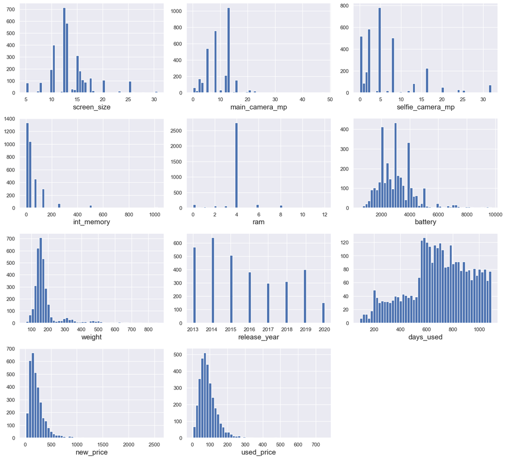

```python
# plotting distributions
plt.figure(figsize=(15, 30))
for i in range(len(numeric_cols)):
    plt.subplot(9, 3, i + 1)
    plt.hist(df[numeric_cols[i]], bins=50)
    plt.tight_layout()
    plt.xlabel(numeric_cols[i], fontsize=15)
plt.show()
```

Observations:

- Most of the variables have a very skewed distribution
  - Linear regression models assume variables follow a normal distribution
  - Skewed data may cause the model to overweight the influence of extreme values
    - Skewness
    - outliers
- log transformation will be applied to deal with skewness

```python
# Applying log transformation to all numeric columns
for col in numeric_cols:
    df[col + "_log"] = np.log(df[col]+1)

# dropping the original numeric columns
df.drop(numeric_cols,axis=1, inplace=True)
df.head()
```

|  | brand_name | os | 4g | 5g | screen_size_log | main_camera_mp_log | selfie_camera_mp_log | int_memory_log | ram_log | battery_log | weight_log | release_year_log | days_used_log | new_price_log | used_price_log |
| --- | --- | --- | --- | --- | --- | --- | --- | --- | --- | --- | --- | --- | --- | --- | --- |
| 0 | Honor | Android | yes | no | 2.740840 | 2.639057 | 1.791759 | 4.174387 | 1.386294 | 8.013343 | 4.990433 | 7.611348 | 4.852030 | 4.724019 | 4.320949 |
| 1 | Honor | Android | yes | yes | 2.906901 | 2.639057 | 2.833213 | 4.859812 | 2.197225 | 8.366603 | 5.365976 | 7.611348 | 5.786897 | 5.523020 | 5.167810 |
| 2 | Honor | Android | yes | yes | 2.873000 | 2.639057 | 2.197225 | 4.859812 | 2.197225 | 8.343078 | 5.365976 | 7.611348 | 5.093750 | 5.887409 | 5.117095 |
| 3 | Honor | Android | yes | yes | 3.277145 | 2.639057 | 2.197225 | 4.174387 | 1.945910 | 8.888895 | 6.175867 | 7.611348 | 5.846439 | 5.634540 | 5.141254 |
| 4 | Honor | Android | yes | no | 2.792391 | 2.639057 | 2.197225 | 4.174387 | 1.386294 | 8.517393 | 5.225747 | 7.611348 | 5.683580 | 4.954911 | 4.402319 |

#### Checking Skeweness after the log tranformation

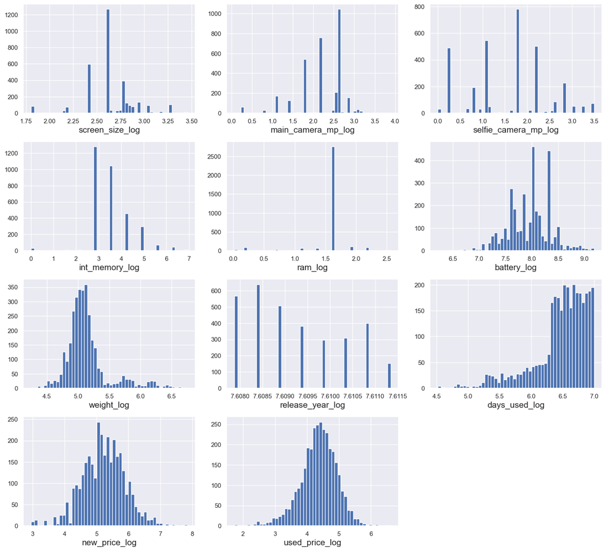

```python
# creating a list of the numerical variables with log transformation
numeric_log_cols = [
    item for item in df.select_dtypes(include=np.number).columns]

# plotting distributions after log transformation
plt.figure(figsize=(15, 30))
for i in range(len(numeric_log_cols)):
    plt.subplot(9, 3, i + 1)
    plt.hist(df[numeric_log_cols[i]], bins=50)
    plt.tight_layout()
    plt.xlabel(numeric_log_cols[i], fontsize=15)
plt.show()
```

Observations:

- The Columns are still skewed, but not as heavily as before.
- target variable looks a lot more normally distributed than before

## 3.2 Checking for outliers

```python
# creating a list of all numerical variables
out_cols = [
    item for item in df.select_dtypes(include=np.number).columns]
```

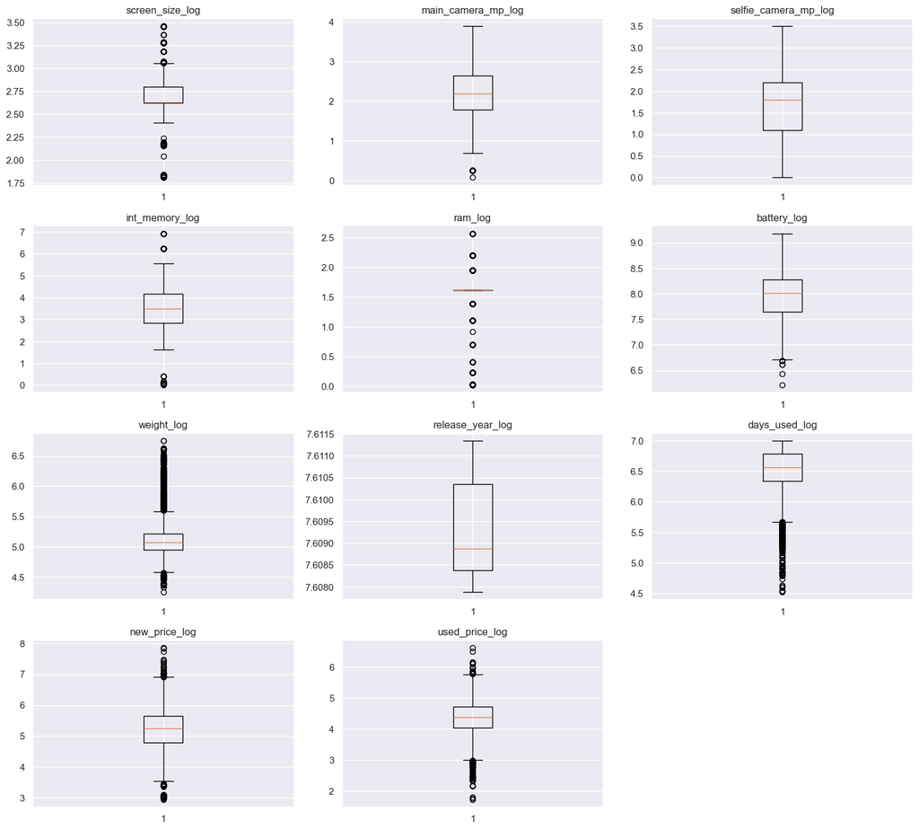

```python
# creating box plots for all numerical variables
plt.figure(figsize=(15, 30))
for i, variable in enumerate(out_cols):
    plt.subplot(9, 3, i + 1)
    plt.boxplot(df[variable], whis=1.5)
    plt.tight_layout()
    plt.title(variable)
plt.show()
```

Observations

- Some of the columns do have outliers in theers
- I will treat these outliers by flooring and capping, except for the ram column since there is not a lot of variation in it.
  - lower outliers by Q1 - 1.5IQR.
  - upper outliers by Q3 + 1.5IQR.

```python
# functions to treat outliers by flooring and capping
def treat_outliers(df, col):
    """
    Treats outliers in a variable

    df: dataframe
    col: dataframe column
    """
    Q1 = df[col].quantile(0.25)  # 25th quantile
    Q3 = df[col].quantile(0.75)  # 75th quantile
    IQR = Q3 - Q1
    Lower_Whisker = Q1 - 1.5 * IQR
    Upper_Whisker = Q3 + 1.5 * IQR

    # all the values smaller than Lower_Whisker will be assigned the value of Lower_Whisker
    # all the values greater than Upper_Whisker will be assigned the value of Upper_Whisker
    df[col] = np.clip(df[col], Lower_Whisker, Upper_Whisker)

    return df

def treat_outliers_all(df, col_list):
    """
    Treat outliers in a list of variables

    df: dataframe
    col_list: list of dataframe columns
    """
    for c in col_list:
        df = treat_outliers(df, c)

    return df
```

```python
# creating a new list that does not include 'ram_log'
treat_out_cols = out_cols
treat_out_cols.remove('ram_log')

# treating outliers
df = treat_outliers_all(df, treat_out_cols)
```

#### Checking Outliers after flooring and capping

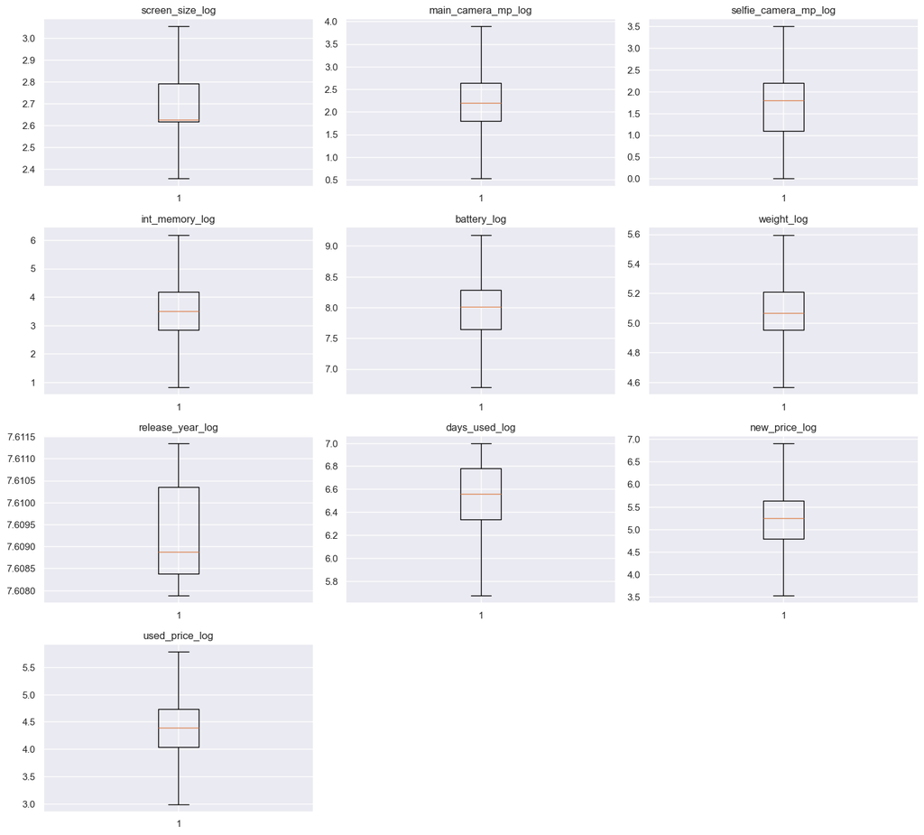

```python
# creating box plots for all numerical variables
plt.figure(figsize=(15, 30))
for i, variable in enumerate(treat_out_cols):
    plt.subplot(9, 3, i + 1)
    plt.boxplot(df[variable], whis=1.5)
    plt.tight_layout()
    plt.title(variable)
plt.show()
```

## 3.3 Encoding Categorical variables

Linear regression models require all variables to be numeric

```python
# creating a list of all categorical variables
cat_cols = df.select_dtypes(include=['object', 'category']).columns.tolist()

# empty list to store dictionaries
cat_list = []

# creating a dictionary of encoded values / Encoding categorical variables
for col in cat_cols:
    cat_list.append(dict( enumerate(df[col].cat.categories )))
    df[col] = df[col].cat.codes

# Empty dictionary to store the mapping of categorical variables and encoded values
category_map = {}

# creating a single map of categories and encoded values
for i in range(len(cat_list)):
    map = {value:key for key, value in cat_list[i].items()}
    category_map.update(map)
```

```python
# looking at encoded columns
df[cat_cols].head()
```

|  | brand_name | os | 4g | 5g |
| --- | --- | --- | --- | --- |
| 0 | 10 | 0 | 1 | 0 |
| 1 | 10 | 0 | 1 | 1 |
| 2 | 10 | 0 | 1 | 1 |
| 3 | 10 | 0 | 1 | 1 |
| 4 | 10 | 0 | 1 | 0 |

All categorical colums have been encoded

## 4. Model

- Build Model
- Evaluate Model
- Make predictions

## 4.1 Building Model

```python
# Independent Variables
X = df.drop(['used_price_log','release_year_log'], axis=1)

# Dependent variable (Target variable)
y = df['used_price_log']
```

```python
# splitting data between training and testing datasets
X_train, X_test, y_train, y_test = train_test_split(X,y,test_size=0.3, random_state=123)
```

```python
# Defining model
model = LinearRegression()

# training model
model.fit(X_train,y_train);
```

## 4.2 Evaluating Model

```python
# function to compute adjusted R-squared
def adj_r2_score(predictors, targets, predictions):
    r2 = r2_score(targets, predictions)
    n = predictors.shape[0]
    k = predictors.shape[1]
    return 1 - ((1 - r2) * (n - 1) / (n - k - 1))


# function to compute MAPE
def mape_score(targets, predictions):
    return np.mean(np.abs(targets - predictions) / targets) * 100


# function to compute different metrics to check performance of a regression model
def model_performance_regression(model, predictors, target):
    """
    Function to compute different metrics to check regression model performance

    model: regressor
    predictors: independent variables
    target: dependent variable
    """

    # predicting using the independent variables
    pred = model.predict(predictors)

    r2 = r2_score(target, pred)  # to compute R-squared
    adjr2 = adj_r2_score(predictors, target, pred)  # to compute adjusted R-squared
    rmse = np.sqrt(mean_squared_error(target, pred))  # to compute RMSE
    mae = mean_absolute_error(target, pred)  # to compute MAE
    mape = mape_score(target, pred)  # to compute MAPE

    # creating a dataframe of metrics
    df_perf = pd.DataFrame(
        {
            "RMSE": rmse,
            "MAE": mae,
            "R-squared": r2,
            "Adj. R-squared": adjr2,
            "MAPE": mape,
        },
        index=[0],
    )

    return df_perf
```

```python
# Checking model performance on train set
print("Training Performance:\n")
model_train_perf = model_performance_regression(model, X_train, y_train)
display(model_train_perf)

# Checking model performance on test set
print("Testing Performance:\n")
model_test_perf = model_performance_regression(model, X_test, y_test)
display(model_test_perf)
```

```
Training Performance:
```

|  | RMSE | MAE | R-squared | Adj. R-squared | MAPE |
| --- | --- | --- | --- | --- | --- |
| 0 | 0.22107 | 0.176037 | 0.837141 | 0.836205 | 4.128578 |

```
Testing Performance:
```

|  | RMSE | MAE | R-squared | Adj. R-squared | MAPE |
| --- | --- | --- | --- | --- | --- |
| 0 | 0.220446 | 0.173873 | 0.831437 | 0.829159 | 4.076869 |

Observations:

- R-squared and adj. R-squared for `training` and `testing` data are very close, meaning the model is not overfitting
- Both RMSE and MAPE are low, therefore the errror between predicitions and actual values is small (MAPE is in percentage; 4.07% difference between predicted and actual values)
- The model can describe ~83.14% of the variance in the data

## 4.3 Making Predictions

since log transformation and encoding was used for the training model, the predicting values need to be transformed aswell

```python
# function to process predicting values
def prediction_values(map,list_):
    if list_:
        categories = [map[value] for value in list_ if isinstance(value,str)]
        numerical = [np.log(value + 1) for value in list_ if isinstance(value,(np.int64,int,float))]
        categories.extend(numerical)
    return categories

# Function to make predictions
def prediction(model,map,list):
    processed = prediction_values(map,list)
    pred = np.exp(model.predict([processed]))
    return round(pred[0],2)
```

Lets try making a prediction on one of the records from the dataset

```python
# create a list of predicting values from the first record of the dataset
list = data.drop(['release_year','used_price'],axis=1).iloc[0].tolist()

# displaying the first cell phone's info
data.iloc[0]
```

```
brand_name            Honor
os                  Android
screen_size            14.5
4g                      yes
5g                       no
main_camera_mp         13.0
selfie_camera_mp        5.0
int_memory             64.0
ram                     3.0
battery              3020.0
weight                146.0
release_year           2020
days_used               127
new_price            111.62
used_price            74.26
Name: 0, dtype: object
```

```python
# making a prediction
pred = prediction(model,category_map,list)
print(f'The predicted used price is: {pred}')
```

```
The predicted used price is: 74.25
```

- It is clear that the model is working correctly
- The prediction was almost perfect

```python
# creating list with the above values
cell_phone = ['Apple','iOS',17.018,'yes','yes',12.0,12.0,128.0,6.0,4352.0,240.0,730,564.57]
```

```python
pred2 = prediction(model,category_map,cell_phone)
print(f'The predicted used price is: {pred2}')
```

```
The predicted used price is: 216.14
```

## 4.4 Understanding the model

A linear regression model attempts to find the linear equation of the line of best fit :

Equation of a line:

$ y = mx + b $

Where:

```
y: dependent variable
m: coefficient (slope)
x: independent variable
b: y-intercept
```

Depending on the number of independent variables the equation can also look like:

$ y = mx_1 + mx_2 + mx_3 + .... + mx_n + b $

```python
# getting the coefficients of the model's linear equation
model.coef_
```

```
array([ 1.80800175e-04,  2.33486491e-02,  1.27872868e-02,  5.67794789e-02,
        5.20526339e-01,  1.58172962e-01,  1.24072600e-01,  2.92327407e-02,
        1.99256950e-03,  1.62064372e-02,  3.03204404e-01, -7.01820362e-03,
        3.81586598e-01])
```

```python
# getting the y-intercept of the model's linear equation
model.intercept_
```

```
-1.3099235106862963
```

```python
# creating a list of the independent variables and modifying the name for simplicity and better visualization of the equation
factors1 = ['Brand','OS','4G','5G','ScreenSize','MainCamera','FrontCamera','Memory','RAM','Battery','Weight','DaysUsed','NewPrice']

# creating a list of the coefficients and reducing the number of digits for simplicity and better visualization of the equation
coefficients = np.around(model.coef_,4).tolist()
```

```python
# creating a string of the full equation of our model
string = ''
for m,x in zip(factors1,coefficients):
    if m != factors1[0] and x > 0:
        string = string + f' + {x}*{m}'
    elif x < 0:
        string = string + f' - {x*-1}*{m}'
    else:
        string = string + f'{x}*{m}'

string = 'y = ' + string + ' ' + str(np.around(model.intercept_,4))
```

```python
string;
```

## Linear Regression Model

** Remember that the independent variables have to be log transformed before being able to plug them in directly (only for this notebook since we used log transform for training data)

$ y = 0.0002*Brand + 0.0233*OS + 0.0128*4G + 0.0568*5G + 0.5205*ScreenSize + 0.1582*MainCamera + 0.1241*FrontCamera + 0.0292*Memory + 0.002*RAM + 0.0162*Battery + 0.3032*Weight - 0.007*DaysUsed + 0.3816*NewPrice -1.3099 $